# Fetal Health Classification

## Fetal Health Classification

The dataset comprises 2126 instances featuring extracted features from Cardiotocogram exams. These instances were classified by three expert obstetricians into three distinct classes:

- Normal (Class 1)
- Suspect (Class 2)
- Pathological (Class 3)

## Key Questions

1. Are there features that exhibit a high correlation with fetal health?
2. What is the distribution of instances across the normal, suspect, and pathological classes in the dataset?
3. Which model performs best in classifying fetal health, and what are the reasons for its superior performance?

## Import Libraries and Load Data

```python
import pandas as pd
import numpy as np
import seaborn as sns
import matplotlib.pyplot as plt
```

```python
from sklearn.model_selection import train_test_split

# Classification modules
from sklearn.linear_model import LogisticRegression
from sklearn.svm import SVC
from sklearn.neighbors import KNeighborsClassifier
from sklearn.tree import DecisionTreeClassifier

# measure "goodness"
from sklearn.metrics import confusion_matrix
from sklearn.metrics import accuracy_score, recall_score, average_precision_score, precision_score
from sklearn.metrics import f1_score, fbeta_score
from sklearn.metrics import roc_auc_score
from sklearn.metrics import precision_recall_fscore_support

# Scaling
from sklearn.preprocessing import StandardScaler
```

```python
df = pd.read_csv("fetal_health.csv")
```

```python
df.head(2)
```

|  | baseline value | accelerations | fetal_movement | uterine_contractions | light_decelerations | severe_decelerations | prolongued_decelerations | abnormal_short_term_variability | mean_value_of_short_term_variability | percentage_of_time_with_abnormal_long_term_variability | ... | histogram_min | histogram_max | histogram_number_of_peaks | histogram_number_of_zeroes | histogram_mode | histogram_mean | histogram_median | histogram_variance | histogram_tendency | fetal_health |
| --- | --- | --- | --- | --- | --- | --- | --- | --- | --- | --- | --- | --- | --- | --- | --- | --- | --- | --- | --- | --- | --- |
| 0 | 120.0 | 0.000 | 0.0 | 0.000 | 0.000 | 0.0 | 0.0 | 73.0 | 0.5 | 43.0 | ... | 62.0 | 126.0 | 2.0 | 0.0 | 120.0 | 137.0 | 121.0 | 73.0 | 1.0 | 2.0 |
| 1 | 132.0 | 0.006 | 0.0 | 0.006 | 0.003 | 0.0 | 0.0 | 17.0 | 2.1 | 0.0 | ... | 68.0 | 198.0 | 6.0 | 1.0 | 141.0 | 136.0 | 140.0 | 12.0 | 0.0 | 1.0 |

2 rows × 22 columns

## Explore Data

```python
print(f"List of columns in data: {list(df.columns)}")
```

[output not shown]

### There are no missing data.

```python
#There are no missing data
df.info()
```

```
<class 'pandas.core.frame.DataFrame'>
RangeIndex: 2126 entries, 0 to 2125
Data columns (total 22 columns):
 #   Column                                                  Non-Null Count  Dtype
---  ------                                                  --------------  -----
 0   baseline value                                          2126 non-null   float64
 1   accelerations                                           2126 non-null   float64
 2   fetal_movement                                          2126 non-null   float64
 3   uterine_contractions                                    2126 non-null   float64
 4   light_decelerations                                     2126 non-null   float64
 5   severe_decelerations                                    2126 non-null   float64
 6   prolongued_decelerations                                2126 non-null   float64
 7   abnormal_short_term_variability                         2126 non-null   float64
 8   mean_value_of_short_term_variability                    2126 non-null   float64
 9   percentage_of_time_with_abnormal_long_term_variability  2126 non-null   float64
 10  mean_value_of_long_term_variability                     2126 non-null   float64
 11  histogram_width                                         2126 non-null   float64
 12  histogram_min                                           2126 non-null   float64
 13  histogram_max                                           2126 non-null   float64
 14  histogram_number_of_peaks                               2126 non-null   float64
 15  histogram_number_of_zeroes                              2126 non-null   float64
 16  histogram_mode                                          2126 non-null   float64
 17  histogram_mean                                          2126 non-null   float64
 18  histogram_median                                        2126 non-null   float64
 19  histogram_variance                                      2126 non-null   float64
 20  histogram_tendency                                      2126 non-null   float64
 21  fetal_health                                            2126 non-null   float64
dtypes: float64(22)
memory usage: 365.5 KB
```

### There are 2126 records and 22 features.

```python
print(f" This dataset has the following shape: {df.shape}")
```

```
 This dataset has the following shape: (2126, 22)
```

### Feature Statistics

```python
df.describe().T.style.background_gradient('PuBu')
```

|  | count | mean | std | min | 25% | 50% | 75% | max |
| --- | --- | --- | --- | --- | --- | --- | --- | --- |
| baseline value | 2126.000000 | 133.303857 | 9.840844 | 106.000000 | 126.000000 | 133.000000 | 140.000000 | 160.000000 |
| accelerations | 2126.000000 | 0.003178 | 0.003866 | 0.000000 | 0.000000 | 0.002000 | 0.006000 | 0.019000 |
| fetal_movement | 2126.000000 | 0.009481 | 0.046666 | 0.000000 | 0.000000 | 0.000000 | 0.003000 | 0.481000 |
| uterine_contractions | 2126.000000 | 0.004366 | 0.002946 | 0.000000 | 0.002000 | 0.004000 | 0.007000 | 0.015000 |
| light_decelerations | 2126.000000 | 0.001889 | 0.002960 | 0.000000 | 0.000000 | 0.000000 | 0.003000 | 0.015000 |
| severe_decelerations | 2126.000000 | 0.000003 | 0.000057 | 0.000000 | 0.000000 | 0.000000 | 0.000000 | 0.001000 |
| prolongued_decelerations | 2126.000000 | 0.000159 | 0.000590 | 0.000000 | 0.000000 | 0.000000 | 0.000000 | 0.005000 |
| abnormal_short_term_variability | 2126.000000 | 46.990122 | 17.192814 | 12.000000 | 32.000000 | 49.000000 | 61.000000 | 87.000000 |
| mean_value_of_short_term_variability | 2126.000000 | 1.332785 | 0.883241 | 0.200000 | 0.700000 | 1.200000 | 1.700000 | 7.000000 |
| percentage_of_time_with_abnormal_long_term_variability | 2126.000000 | 9.846660 | 18.396880 | 0.000000 | 0.000000 | 0.000000 | 11.000000 | 91.000000 |
| mean_value_of_long_term_variability | 2126.000000 | 8.187629 | 5.628247 | 0.000000 | 4.600000 | 7.400000 | 10.800000 | 50.700000 |
| histogram_width | 2126.000000 | 70.445908 | 38.955693 | 3.000000 | 37.000000 | 67.500000 | 100.000000 | 180.000000 |
| histogram_min | 2126.000000 | 93.579492 | 29.560212 | 50.000000 | 67.000000 | 93.000000 | 120.000000 | 159.000000 |
| histogram_max | 2126.000000 | 164.025400 | 17.944183 | 122.000000 | 152.000000 | 162.000000 | 174.000000 | 238.000000 |
| histogram_number_of_peaks | 2126.000000 | 4.068203 | 2.949386 | 0.000000 | 2.000000 | 3.000000 | 6.000000 | 18.000000 |
| histogram_number_of_zeroes | 2126.000000 | 0.323612 | 0.706059 | 0.000000 | 0.000000 | 0.000000 | 0.000000 | 10.000000 |
| histogram_mode | 2126.000000 | 137.452023 | 16.381289 | 60.000000 | 129.000000 | 139.000000 | 148.000000 | 187.000000 |
| histogram_mean | 2126.000000 | 134.610536 | 15.593596 | 73.000000 | 125.000000 | 136.000000 | 145.000000 | 182.000000 |
| histogram_median | 2126.000000 | 138.090310 | 14.466589 | 77.000000 | 129.000000 | 139.000000 | 148.000000 | 186.000000 |
| histogram_variance | 2126.000000 | 18.808090 | 28.977636 | 0.000000 | 2.000000 | 7.000000 | 24.000000 | 269.000000 |
| histogram_tendency | 2126.000000 | 0.320320 | 0.610829 | -1.000000 | 0.000000 | 0.000000 | 1.000000 | 1.000000 |
| fetal_health | 2126.000000 | 1.304327 | 0.614377 | 1.000000 | 1.000000 | 1.000000 | 1.000000 | 3.000000 |

### Heatmap

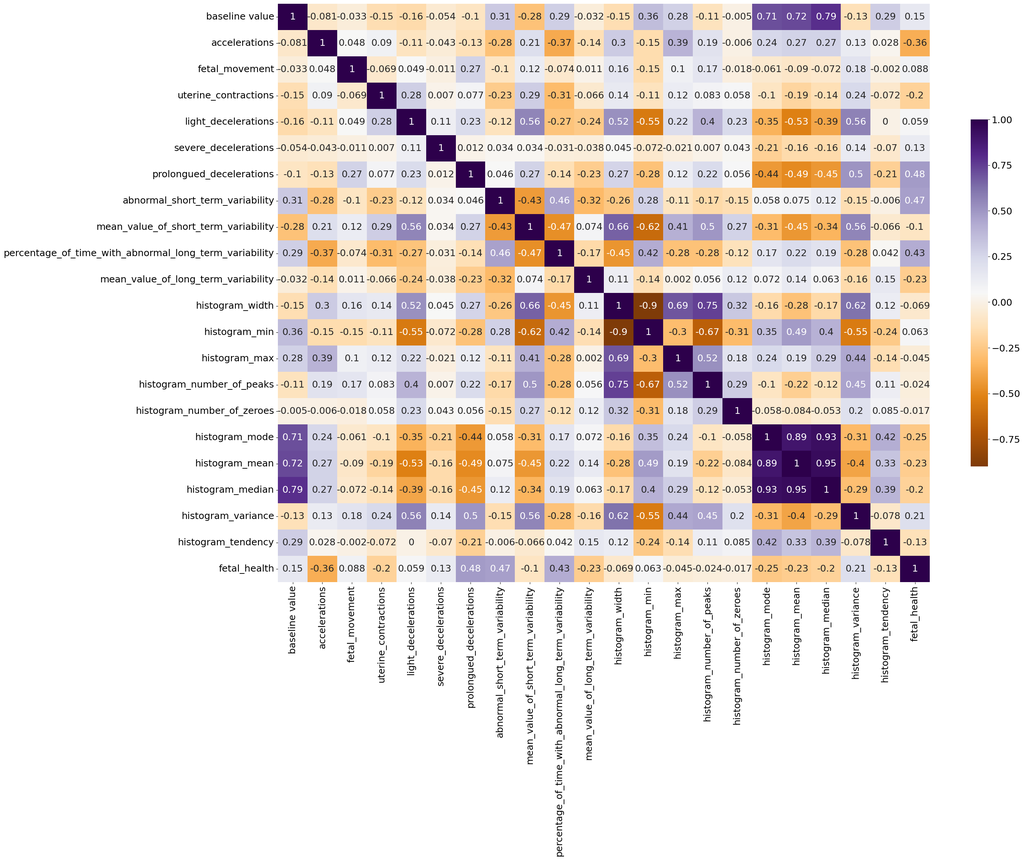

```python
plt.figure(figsize=(28,20))
heatmap=sns.heatmap(df.corr(numeric_only=True).round(3), cmap='PuOr', annot=True, annot_kws={"size": 18},
                    cbar_kws={"shrink":0.6})
heatmap.set_xticklabels(heatmap.get_xticklabels(), fontsize=18)
heatmap.set_yticklabels(heatmap.get_yticklabels(), fontsize=18)
cbar = heatmap.collections[0].colorbar
cbar.ax.tick_params(labelsize=18)
plt.show()
```

### Fetal Health Class Distribution

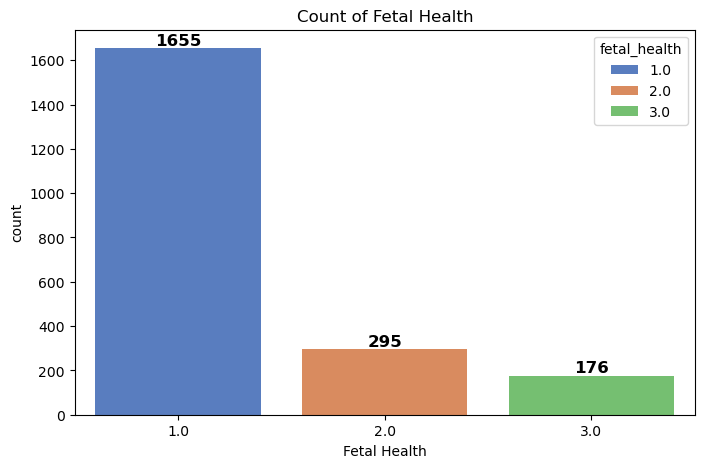

```python
plt.figure(figsize=(8, 5))
ax = plt.subplot(1, 1, 1)

sns.countplot(data=df, x="fetal_health", palette='muted', hue="fetal_health", ax=ax)

for container in ax.containers:
    ax.bar_label(container, fmt='%.0f', fontsize=12, weight='bold')

plt.title('Count of Fetal Health')
plt.xlabel('Fetal Health')
plt.show()
```

## Classification Model

```python
#Split training and testing data
X = df.drop(columns="fetal_health", axis = 1)
y = df.fetal_health
X_train, X_test, y_train, y_test = train_test_split(X, y,
                                                   test_size=0.2,
                                                   random_state=42)
s_scaler = StandardScaler().fit(X_train)
```

### Scale Data

```python
X_train_scaled = pd.DataFrame(s_scaler.transform(X_train), columns=X_train.columns)
X_train_scaled.shape
```

```
(1700, 21)
```

```python
X_test_scaled = pd.DataFrame(s_scaler.transform(X_test), columns=X_test.columns)
X_test_scaled.shape
```

```
(426, 21)
```

### Initialize Classifiers

```python
logReg = LogisticRegression()
svmClassifier = SVC(probability=True)
knnClassifier = KNeighborsClassifier()
dtClassifier = DecisionTreeClassifier()
```

```python
def calculate_metrics_multiclass(classifier, name, X_test, y_test):
    metrics = {}
    classifier.fit(X_train_scaled, y_train)
    predictions = classifier.predict(X_test)
    #Compare models
    metrics['accuracy'] = accuracy_score(y_test, predictions)
    metrics['recall'] = recall_score(y_test, predictions, average='macro')
    metrics['precision'] = precision_score(y_test, predictions, average='macro')
    metrics['f2_score'] = fbeta_score(y_test, predictions, average='macro', beta= 2)
    # Confusion matrix for multiclass
    conf_matrix = confusion_matrix(y_test, predictions)
    metrics['confusion_matrix'] = conf_matrix
    # ROC AUC score
    if hasattr(classifier, "classes_") and len(classifier.classes_) > 2:
        roc_auc_scores = []
        for i in range(len(classifier.classes_)):
            true_labels = (y_test == classifier.classes_[i]).astype(int)
            predicted_probs = classifier.predict_proba(X_test)[:, i]
            roc_auc_scores.append(roc_auc_score(true_labels, predicted_probs))

        metrics['roc_auc_score'] = np.mean(roc_auc_scores)
    else:
        metrics['roc_auc_score'] = None

    result_df = pd.DataFrame({name: metrics})
    return result_df
```

### Model Evaluation

```python
models = [
    (logReg, 'logistic_regression'),
    (svmClassifier, 'svm'),
    (knnClassifier, 'k_nearest_neighbor'),
    (dtClassifier, 'decision_tree')
]

calculate_metrics = lambda model: calculate_metrics_multiclass(model[0], model[1], X_test_scaled, y_test)

metrics_df = pd.concat(list(map(calculate_metrics, models)), axis=1)

metrics_df.T
```

|  | accuracy | confusion_matrix | f2_score | precision | recall | roc_auc_score |
| --- | --- | --- | --- | --- | --- | --- |
| logistic_regression | 0.877934 | [[311, 19, 3], [18, 41, 5], [2, 5, 22]] | 0.775704 | 0.767893 | 0.777727 | 0.958552 |
| svm | 0.903756 | [[317, 15, 1], [17, 46, 1], [2, 5, 22]] | 0.816747 | 0.852363 | 0.809774 | 0.971001 |
| k_nearest_neighbor | 0.915493 | [[324, 7, 2], [16, 44, 4], [4, 3, 22]] | 0.813384 | 0.847463 | 0.806365 | 0.943848 |
| decision_tree | 0.934272 | [[316, 14, 3], [9, 54, 1], [1, 0, 28]] | 0.910745 | 0.879481 | 0.919405 | 0.933657 |

### Decision Tree Confusion Matrix

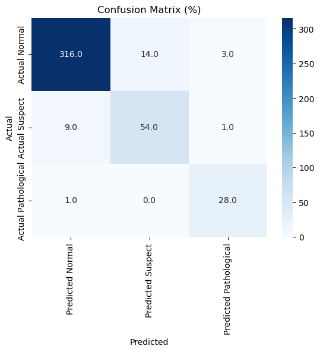

```python
cm = confusion_matrix(y_test, dtClassifier.predict(X_test_scaled))
sns.heatmap(cm, annot=True, fmt='.1f', cmap='Blues',xticklabels=['Predicted Normal', 'Predicted Suspect',
                    'Predicted Pathological'],yticklabels=['Actual Normal', 'Actual Suspect', 'Actual Pathological'])
plt.title('Confusion Matrix (%)')
plt.xlabel('Predicted')
plt.ylabel('Actual')
plt.show()
```

## Summary

1. There isn't a feature in the dataset exhibiting a notably strong correlation with fetal health.
2. The distribution of fetal health classes—normal, suspect, pathological—is 1655:295:176.
3. For this dataset, the decision tree is the preferred classifier due to its superior accuracy and recall, as evident in the F2 score. Emphasizing the minimization of false negatives, recall takes precedence over precision. Moreover, the decision tree exhibits higher precision compared to other classifiers.

Reference:

- Ayres de Campos et al. (2000) SisPorto 2.0 A Program for Automated Analysis of Cardiotocograms. J Matern Fetal Med 5:311-318